# Comparing Gene Expression Patterns between Neuroblastoma Cell Lines

Chloe Brook

# Data Introduction

- Whole-transcriptome RNA-Seq data for 38 neuroblastoma cell lines and 3 non-neuroblastoma cell lines (*RPE-1, human fetal brain tissue, and rhabdomyosarcoma*) was published by [Harenza et al. (2017)](https://www.nature.com/articles/sdata201733).
- Table containing processed **FPKM** data for each cell line was provided: will use this to look at expression of different genes in each cell line.

> **FPKM**: Gene fragments per kilobase of exons per million reads.  
> Used as a **measure of relative gene expression**.
- **MYCN amplification status** of each cell line was also provided in a separate text file.
- The MYCN gene encodes the N-Myc helix-loop-helix protein.
- Elevated MYCN gene copy number in neuroblastoma tumours is a known indicator of poor prognosis [(Tonini et al. 1997)](https://www.ncbi.nlm.nih.gov/pubmed/8996128)

**NOTE**: a [corrigendum](https://www.ncbi.nlm.nih.gov/pmc/articles/PMC5716011/) to the dataset was issued in December 2017, stating that the NB-16 cell line had been incorrectly labelled and was actually a rhabdomyosarcoma cell line (RD). Data sets have been modified to reflect this.

## Aims

- Study how gene expression varies between different cell lines used in neuroblastoma research, focusing on the **differences between MYCN-amplified and non-amplified cell lines**.
- Compare **mean FPKM levels** of all genes in each cell line to see whether **overall levels of gene expression vary between cell lines**.
- Look at the **expression patterns of individual genes** across cell lines.
- Look at cell lines with **similar patterns of overall gene expression**, and highlight outlying cell lines.

# Cell Lines

Shown below is a table summarising the genetic lesion profiles of each neuroblastoma cell line sequenced by Harenza et al. Each genetic aberration contained in the columns is known to be significant in the disease phenotype of neuroblastoma.  
**MYCN-amplified** cell lines are coloured in **red**.

| Cell Line | MYCN status | 1p36 del | 3p26 del | 11q23 del | 17q21-qter unbal gain | ALK mutation | p53 mutation |
| --- | --- | --- | --- | --- | --- | --- | --- |
| CHP-134 | Amplified | LOH p32.3-pter; Gain p34.3-p36.22; Loss p36.22-pter | Gain/AI p26.3 | None | Gain q12-qter | WT | WT |
| CHP-212 | Amplified | Loss p13.2-pter | Gain/AI p26.3 | cnLOH 23.3 | Gain q12-qter | WT | WT |
| COG-N-415 | Amplified | Unknown | Unknown | Unknown | Unknown | F1174L | WT |
| COG-N-440 | Amplified | Unknown | Unknown | Unknown | Unknown | WT | WT |
| COG-N-453 | Amplified | Unknown | Unknown | Unknown | Unknown | F1174L | WT |
| COG-N-471nb | Amplified | Unknown | Unknown | Unknown | Unknown | WT | WT |
| COG-N-496 | Amplified | Unknown | Unknown | Unknown | Unknown | Unknown | Unknown |
| COG-N-519 | Amplified | Unknown | Unknown | Unknown | Unknown | Unknown | Unknown |
| COG-N-534 | Non-amplified | Unknown | Unknown | Unknown | Unknown | Unknown | Unknown |
| COG-N-549 | Non-amplified | Unknown | Unknown | Unknown | Unknown | Unknown | Unknown |
| COG-N-557nb | Amplified | Unknown | Unknown | Unknown | Unknown | Unknown | Unknown |
| COG-N-561 | Amplified | Unknown | Unknown | Unknown | Unknown | Unknown | Unknown |
| COG-N-573 | Amplified | Unknown | Unknown | Unknown | Unknown | Unknown | Unknown |
| FELIX (COG-N-426) | Non-amplified | Unknown | Unknown | Unknown | Unknown | F1245C | WT |
| IMR-05 | Amplified | Gain+LOH p32.3-pter | Gain/AI p24.3-26.3 | Loss q22.1-qter | Gain q21.2-qter | WT | WT |
| IMR-32 | Amplified | Loss p32.3-pter | Loss p12.3 | cnLOH q23.1 | Gain q21.2-qter | WT | WT |
| KELLY | Amplified | LOH p21.3-pter; Loss p36.32; Gain p36.33 | Loss p26.2 | Loss q23.3-qter | Gain q21.2-qter | F1174L | P177T |
| LA-N-5 | Amplified | Loss p33-pter | None | None | Gain q21.2-qter | R1275Q | WT |
| LA-N-6 | Non-amplified | p36.12-pter; cnLOH p35.3-p36.11 | Loss p14.3-pter | Loss q13.4-qter | Gain q12-qter | WT | WT |
| NB-1 | Amplified | Loss p32.2-pter | Gain p24.1-pter | cnLOH q23.1 | Gain q22-qter | WT; amplified | WT |
| RD | Non-amplified | None | None | None | Unresolvable | WT | R248W, R175H |
| NB-1,643 | Amplified | Loss p34.2-pter | None | Loss q23.1-qter | Gain q21.31-qter | R1275Q | WT |
| NB-1,691 | Amplified | None | Loss p26.1 | LOH q11-qter; Loss q22.1-q24.3 | None? | WT | WT |
| NB-69 | Non-amplified | Loss p13.3-pter | None | cnLOH q23.1, q23.3 | Gain q12-qter | WT | WT |
| NB-EBc1 | Non-amplified | Loss p35.2-pter | Gain p26.1-pter | Loss q21-24.2 | Gain q21.31-qter | WT | WT |
| NB-SD | Amplified | Loss p21.3-pter | Loss p13-pter | cnLOH q23.2-23.3 | Gain q12-qter | F1174L | C176F |
| NBL-S | Non-amplified | None | None | Loss q14.1-qter | None | WT | WT |
| NGP | Amplified | cnLOH p32.3-pter | Gain p25.3-pter | Loss q22.1-qter | Gain q21.1-qter | WT | A159D, C141W |
| NLF | Amplified | Loss p32.2-pter | Loss/AI p26.1; AI p26.2; Gain 26.3 | Loss/AI q23.3-qter | Gain q21.2-qter | WT | V203M |
| NMB | Amplified | cnLOH p34.2-pter | None | Loss q21-qter | LOH/Gain q11.2-qter | WT | G245S |
| RPE-1 | Non-amplified | Unknown | Unknown | Unknown | Unknown | WT | WT |
| SH-SY5Y | Non-amplified | None | None | Loss q22.1-q24.2 | Gain q21.31-qter | F1174L | WT |
| SK-N-AS | Non-amplified | Loss p36.22-36.32 | Loss p14.2-pter | q13.4-qter | Gain q21.31-qter | WT | H168R |
| SK-N-BE(2) | Amplified | cnLOH p21.3-pter | Loss p14.2-pter | Gain/AI q13.1-qter | Gain q12-qter | WT | C135F |
| SK-N-BE(2)-C | Amplified | cnLOH p21.3-pter | Loss p14.2-pter | LOH q11-qter; Gain q13.4-qter | Gain q12-qter | WT | C135F |
| SK-N-DZ | Amplified | None | Gain/AI p26.1-pter | Loss q21-qter | Gain q21.2-qter | WT | R110L |
| SK-N-FI | Non-amplified | None | None | None | Gain q21.31-qter | WT | M246R |
| SK-N-SH | Non-amplified | None | None | None | Gain q21.31-qter | F1174L | WT |
| SMS-KAN | Amplified | Loss p13.3-pter | None | Loss q14.2-q23.3 | Gain q11.1-qter | WT | WT |
| SMS-SAN | Amplified | Loss p32.3-pter | None | Loss q25 | Gain q21.2-qter | F1174L | WT |

# FPKM Data

The processed FPKM table containing relative gene expression data for each cell line can be found under [GEO accession GSE89413](https://www.ncbi.nlm.nih.gov/geo/query/acc.cgi?acc=GSe89413)  
Shown below is a preview of the data, with FPKM values for **5** genes in **6** neuroblastoma cell lines:

| GeneID | CHP134 | CHP212 | COGN415 | COGN440 | COGN453 | COGN471 |
| --- | --- | --- | --- | --- | --- | --- |
| EAF1 | 8.783210 | 6.863459 | 5.4629312 | 10.10439 | 6.604241 | 4.8665763 |
| SARNP | 12.752439 | 23.717824 | 22.1624066 | 27.40176 | 19.256736 | 9.1573799 |
| CXCR5 | 0.000000 | 0.000000 | 0.0000000 | 0.00000 | 0.000000 | 0.0000000 |
| MAPK7 | 2.778997 | 2.779451 | 2.7184527 | 1.67738 | 3.709534 | 0.9889767 |
| C2 | 0.000000 | 0.000000 | 0.0004432 | 0.00000 | 0.000000 | 0.0000000 |

The full file contains FPKM data for **24759** genes (after removal of **2044** genes that weren’t expressed) in **41** cell lines.  
These cell lines are:  
CHP134, CHP212, COGN415, COGN440, COGN453, COGN471, COGN496, COGN519, COGN534, COGN549, COGN557, COGN561, COGN573, FELIX, HU.FETAL.BRAIN, IMR32, IMR5, KELLY, LAN5, LAN6, NB1, RD, NB1643, NB1691, NB69, NBEBC1, NBLS, NBSD, NGP, NLF, NMB, RPE1, SHSY5Y, SKNAS, SKNBE2, SKNBE2C, SKNDZ, SKNFI, SKNSH, SMSKAN, SMSSAN.

## Mean FPKM Levels of Cell Lines

The average FPKM values for all genes in each cell line were calculated and plotted in the bar chart below. Cell lines were coloured by their MYCN amplification status, to see if this had an effect on overall levels of gene expression within the cell line.

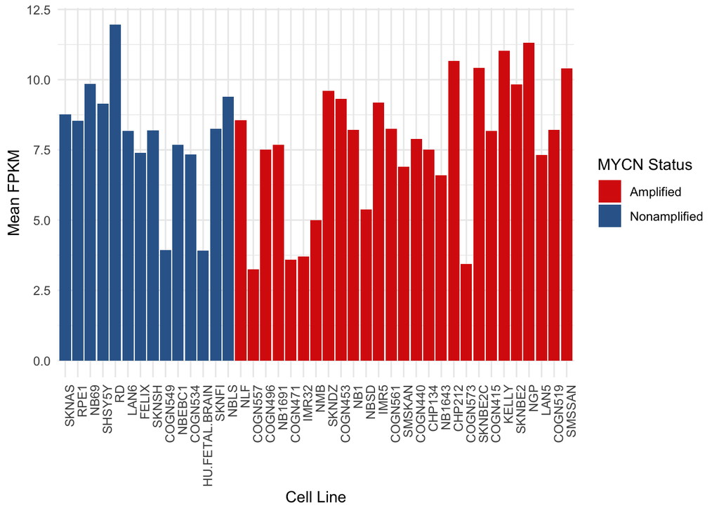

## Gene Expression Heatmap

The 30 most abundant genes across all of the cell lines were selected, and the FPKM values for these genes in each cell line were mapped in the heatmap below. FPKM values were logged to base 10, to highlight differences in gene expression levels.

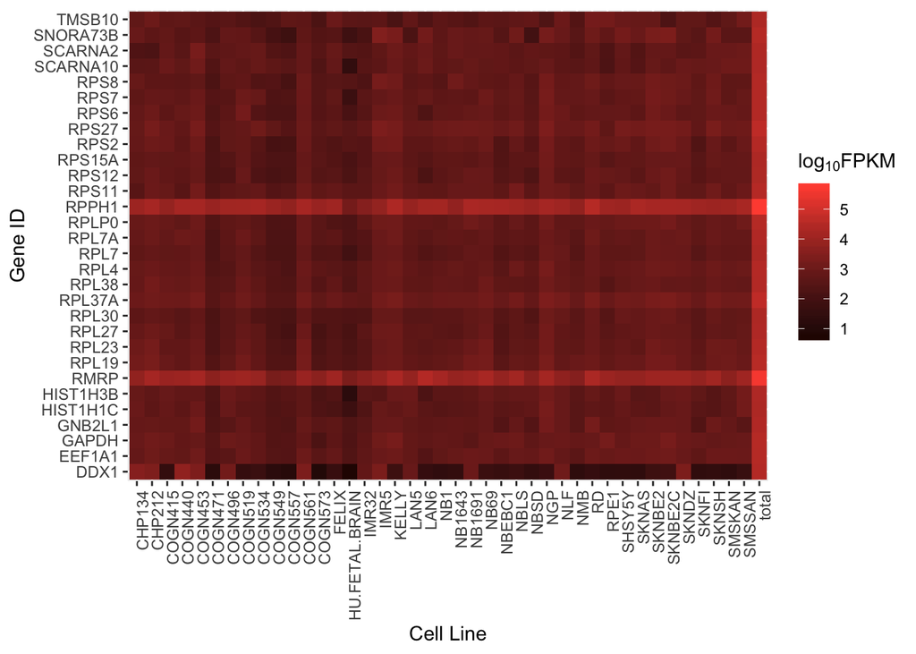

# Principal Component Analysis

Principal component analysis (PCA) is an unsupervised machine learning method used to **simplify data with lots of variables** into smaller dimensions called **‘principal components’**.  
Important features of the data are retained, and can be used to see whether variance is similar between data points (cell lines in this case).

A more thorough explanation of PCA can be found in [this Nature Methods article](https://www.nature.com/articles/nmeth.4346).

## PCA plot

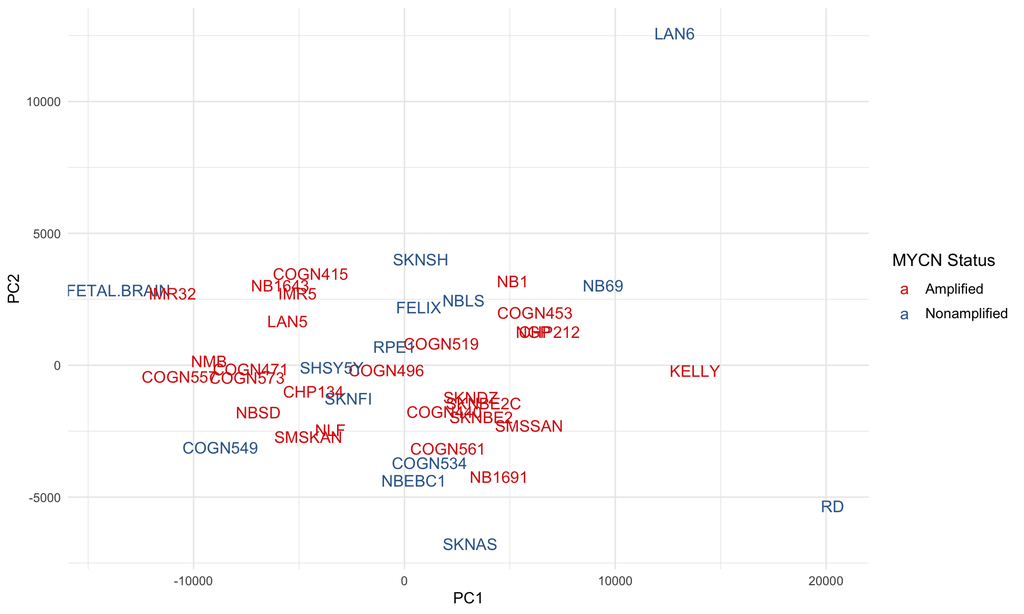

# Conclusions

The PCA plot highlights cell lines with patterns of gene expression that differ greatly from others.

- SK-N-AS
- KELLY
- LAN-6
- RD

**What makes these cell lines different from the others?**

## Further Work

- Investigate genes that are differentially expressed in the outlying cell lines on the PCA plot.
- Study pathways involved in neuroblastoma disease and drug resistance, and make PCA plots to investigate expression of these genes specifically.

# Bibliography

Harenza, J.L., Diamond, M.A., Adams, R.N., Song, M.M., Davidson, H.L., Hart, L.S., Dent, M.H., Fortina, P., Reynolds, C.P. and Maris, J.M., 2017. Transcriptomic profiling of 39 commonly-used neuroblastoma cell lines. Scientific data, 4, p.170033.

Tonini, G.P., Boni, L., Pession, A. and Rogers, D., 1997. MYCN Oncogene Amplification in Neuroblastoma is Associated With Worse Prognosis, Except in Stage 4s: The Italian Experience With 295 Children. Journal of Clinical Oncology, 15(1), pp.85-93.

Lever, J., Krzywinski, M. and Altman, N., 2017. Points of significance: Principal component analysis.

# Package References

R Core Team (2018). R: A language and environment for statistical computing. R Foundation for Statistical Computing, Vienna, Austria.  
URL https://www.R-project.org/.

JJ Allaire, Yihui Xie, Jonathan McPherson, Javier Luraschi, Kevin Ushey, Aron Atkins, Hadley Wickham, Joe Cheng and Winston Chang (2018). rmarkdown: Dynamic Documents for R.  
R package version 1.10.  
https://CRAN.R-project.org/package=rmarkdown

Yihui Xie (2018). knitr: A General-Purpose Package for Dynamic Report Generation in R.  
R package version 1.20.

Yihui Xie (2015) Dynamic Documents with R and knitr. 2nd edition. Chapman and Hall/CRC. ISBN 978-1498716963

Yihui Xie (2014) knitr: A Comprehensive Tool for Reproducible Research in R. In Victoria Stodden, Friedrich Leisch and Roger D. Peng, editors, Implementing Reproducible Computational Research. Chapman and Hall/CRC. ISBN 978-1466561595

H. Wickham. ggplot2: Elegant Graphics for Data Analysis. Springer-Verlag New York, 2016.

Stefan Milton Bache and Hadley Wickham (2014). magrittr:A Forward-Pipe Operator for R.  
R package version 1.5.  
https://CRAN.R-project.org/package=magrittr

Rinker, T. W. & Kurkiewicz, D. (2017). pacman: Package Management for R. version 0.4.6. University at Buffalo. Buffalo, New York.  
http://github.com/trinker/pacman

Hadley Wickham (2016). rvest: Easily Harvest (Scrape) Web Pages.  
R package version 0.3.2.  
https://CRAN.R-project.org/package=rvest

Hadley Wickham and Lionel Henry (2018). tidyr: Easily Tidy Data with ‘spread()’ and ‘gather()’ Functions.  
R package version 0.8.1.  
https://CRAN.R-project.org/package=tidyr

Hadley Wickham, Romain Fran?ois, Lionel Henry and Kirill M?ller (2018). dplyr: A Grammar of Data Manipulation.  
R package version 0.7.7.  
https://CRAN.R-project.org/package=dplyr